# Part I - Prosper Loan Data

## Introduction

Proper Loan Data is to be investigated to find insights for Borrowers and Lenders, it involves an analyis of the Prosper Native Rating System for Borrowers and subsets during the course of the investigation the dataset into finished loan transactions for post-loan analysis.

```python
# import all packages and set plots to be embedded inline
import numpy as np
import pandas as pd
import matplotlib.pyplot as plt
import seaborn as sb
import datetime

import subprocess
import warnings
warnings.simplefilter("ignore")

%matplotlib inline
```

```python
df = pd.read_csv('prosperLoanData.csv')
```

### What is the structure of your dataset?

```python
df.head()
```

|  | ListingKey | ListingNumber | ListingCreationDate | CreditGrade | Term | LoanStatus | ClosedDate | BorrowerAPR | BorrowerRate | LenderYield | ... | LP_ServiceFees | LP_CollectionFees | LP_GrossPrincipalLoss | LP_NetPrincipalLoss | LP_NonPrincipalRecoverypayments | PercentFunded | Recommendations | InvestmentFromFriendsCount | InvestmentFromFriendsAmount | Investors |
| --- | --- | --- | --- | --- | --- | --- | --- | --- | --- | --- | --- | --- | --- | --- | --- | --- | --- | --- | --- | --- | --- |
| 0 | 1021339766868145413AB3B | 193129 | 2007-08-26 19:09:29.263000000 | C | 36 | Completed | 2009-08-14 00:00:00 | 0.16516 | 0.1580 | 0.1380 | ... | -133.18 | 0.0 | 0.0 | 0.0 | 0.0 | 1.0 | 0 | 0 | 0.0 | 258 |
| 1 | 10273602499503308B223C1 | 1209647 | 2014-02-27 08:28:07.900000000 | NaN | 36 | Current | NaN | 0.12016 | 0.0920 | 0.0820 | ... | 0.00 | 0.0 | 0.0 | 0.0 | 0.0 | 1.0 | 0 | 0 | 0.0 | 1 |
| 2 | 0EE9337825851032864889A | 81716 | 2007-01-05 15:00:47.090000000 | HR | 36 | Completed | 2009-12-17 00:00:00 | 0.28269 | 0.2750 | 0.2400 | ... | -24.20 | 0.0 | 0.0 | 0.0 | 0.0 | 1.0 | 0 | 0 | 0.0 | 41 |
| 3 | 0EF5356002482715299901A | 658116 | 2012-10-22 11:02:35.010000000 | NaN | 36 | Current | NaN | 0.12528 | 0.0974 | 0.0874 | ... | -108.01 | 0.0 | 0.0 | 0.0 | 0.0 | 1.0 | 0 | 0 | 0.0 | 158 |
| 4 | 0F023589499656230C5E3E2 | 909464 | 2013-09-14 18:38:39.097000000 | NaN | 36 | Current | NaN | 0.24614 | 0.2085 | 0.1985 | ... | -60.27 | 0.0 | 0.0 | 0.0 | 0.0 | 1.0 | 0 | 0 | 0.0 | 20 |

5 rows × 81 columns

```python
df.info()
```

```
<class 'pandas.core.frame.DataFrame'>
RangeIndex: 113937 entries, 0 to 113936
Data columns (total 81 columns):
 #   Column                               Non-Null Count   Dtype
---  ------                               --------------   -----
 0   ListingKey                           113937 non-null  object
 1   ListingNumber                        113937 non-null  int64
 2   ListingCreationDate                  113937 non-null  object
 3   CreditGrade                          28953 non-null   object
 4   Term                                 113937 non-null  int64
 5   LoanStatus                           113937 non-null  object
 6   ClosedDate                           55089 non-null   object
 7   BorrowerAPR                          113912 non-null  float64
 8   BorrowerRate                         113937 non-null  float64
 9   LenderYield                          113937 non-null  float64
```

[output cut: 73 more lines]

```python
# number rows
df.shape[0]
```

```
113937
```

```python
# number columns
df.shape[1]
```

```
81
```

The dataset comprises of a bit more than 110k observations/rows that collected datapoints for 81 rows if observations where available. While there are several columns which only started to collect data after 2009, these columns and others have a considerable amount of missing values and will mostly not be used, generally though the dataset is very complete and most columns can be investigated.

### What is/are the main feature(s) of interest in your dataset?

```python
# Investing of post 2009 data recording for "CreditGrade" rating system showed a large number of NaN values.
df.CreditGrade.isna().sum()
```

```
84984
```

```python
# Feature engineer "Average Credit Score" - Data Source is the Consumer Credit Rating Agency
df['AverageCreditScore'] = (df['CreditScoreRangeLower']+ df['CreditScoreRangeUpper'] )/2
```

```python
# In-house Prosper Borrower Rating System
df[['ProsperScore', 'ProsperRating (numeric)', 'CreditGrade', 'AverageCreditScore']].info()
```

```
<class 'pandas.core.frame.DataFrame'>
RangeIndex: 113937 entries, 0 to 113936
Data columns (total 4 columns):
 #   Column                   Non-Null Count   Dtype
---  ------                   --------------   -----
 0   ProsperScore             84853 non-null   float64
 1   ProsperRating (numeric)  84853 non-null   float64
 2   CreditGrade              28953 non-null   object
 3   AverageCreditScore       113346 non-null  float64
dtypes: float64(3), object(1)
memory usage: 3.5+ MB
```

Main insights can be drawn from both, a lenders and borrowers perspective. For the lender an evaluation of available borrower rating systems can be prioritized, columns that give feedback on borrowers are described in the code cell above: **ProsperScore**, **ProsperRating**, and **AverageCreditScore**. The column *CreditGrade* will not be considered due to missing datapoints (see Non-Null Count above).

The analysis of the features above will on a first level be conducted by its relation to borrowers ability to uphold their loan agreements, a subset of the dataset that post-loan analyzes loan outcome will be done by the **LoanStatus** column - categorized into "Completed", "Defaulted", "Chargedoff" loans - and **AmountDelinquent** column as benchmarks.

Further for estimating a lenders market liquidity and overhead, the average timespan of loans will be be investigated in relation to loan agreement - *Term* - and others.

### What features in the dataset do you think will help support your investigation into your feature(s) of interest?

Columns that directly affect the transaction from Ratings and Loan Outcome, will be the InterestRate of the Borrower - the dataset subdivided this interest rate into several columns to individually outline "lender-yield" or "paid service-fee", the summation of all Interest towards the borrower side is the column **BorrowerAPR** will will be mainly used going forward. Further the size of the loans in terms of **OriginalAmount** will be considered, next the borrowers cashflow and asset-availability through columns like, **EmploymentStatus**, **Occupation**, **IsHomeOwner**, and other will be investigated with a peak look into the borrowers reputation amongs **Investors**, **Recommendations**, and **InvestmentFromFriendsAmount** columns.

## Preliminary Wrangling

### Data Tidiness step for time plot analysis

```python
# Datetime conversions
df.ListingCreationDate = pd.to_datetime(df.ListingCreationDate)
df.ClosedDate = pd.to_datetime(df.ClosedDate)
df.DateCreditPulled =pd.to_datetime(df.DateCreditPulled)
df.FirstRecordedCreditLine = pd.to_datetime(df.FirstRecordedCreditLine)
df.LoanOriginationDate = pd.to_datetime(df.LoanOriginationDate)
```

### Generig Histogram and Countplot Functions for iterative usage

```python
def countplot(data, x=None, y=None,hue=None, figsize=(6,4), color=sb.color_palette()[0], x_rotation=0, y_rotation=0):
    plt.figure(figsize=figsize)
    sb.countplot(data=data, y=y, x=x, hue=hue, color=color)
    plt.xticks(rotation=x_rotation)
    plt.yticks(rotation=y_rotation);
```

```python
def hist(data, x=None, figsize=(6,4), color=sb.color_palette()[0], x_rotation=0, y_rotation=0, bins=None):
    plt.figure(figsize=figsize)
    plt.hist(data=data, x=x, color=color, bins=bins)
    plt.xticks(rotation=x_rotation)
    plt.yticks(rotation=y_rotation);
```

## Univariate Exploration

**Question 1.** What is the borrower Interest Rate composition of the dataset?

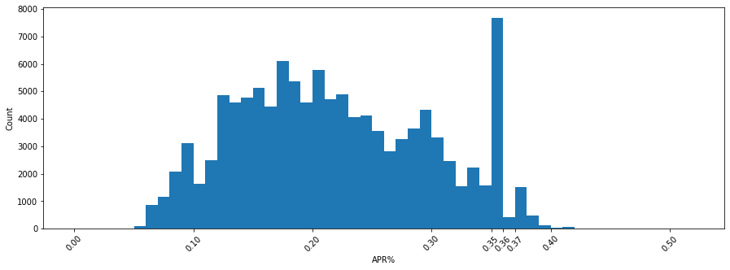

```python
# Borrower APR - includes Borrower Interes rate + any other fees
bins = np.arange(0, df.BorrowerAPR.max()+.01,.01)

hist(data=df,  x='BorrowerAPR', figsize=(15,5), x_rotation=45, bins=bins)
plt.xlabel('APR%')
plt.ylabel('Count')
plt.xticks([0.0,0.1,0.2,0.3,0.35,0.36,0.37,0.4,.5]);
```

```python
# Outlier bin evaluation of ≈ 36% InterestRate Loans
outlier = df.query("BorrowerAPR > 0.35 and BorrowerAPR < 0.37")
outlier.shape[0]
```

```
8088
```

```python
outlier[['ProsperRating (numeric)', 'LoanOriginalAmount']].mean()
```

```
ProsperRating (numeric)       1.308689
LoanOriginalAmount         3925.955613
dtype: float64
```

```python
df[['ProsperRating (numeric)', 'LoanOriginalAmount']].mean()
```

```
ProsperRating (numeric)       4.072243
LoanOriginalAmount         8337.013850
dtype: float64
```

**Observation:** The general peak of loans are opened with ≈ 17% BorrowerAPR, in a slight/moderate right-skewed distribution, with however a large bin of more than 8000 Loans with ≈ 36% Interest. A quick visual comparison showed this outlier to be of low rated borrowers for relatively small Loans in terms of amount, as expected.

**Question 2.:** What are the borrowers professions at the time of the request of the loan (Loan listing)?

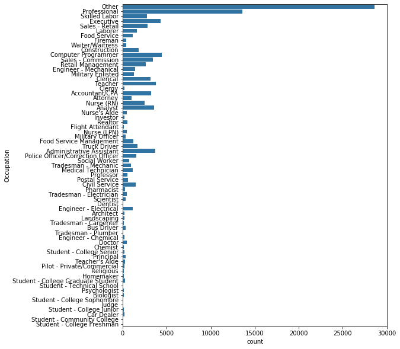

```python
countplot(df,y = 'Occupation', figsize= (8,10))
```

**Observation:** While a large number of listings did not hold specific information about borrowers occupation, for those who gave information a significantly larger numbero of listings occured by white collar professions. Given the presumption that these are likely to have lower Interest Rate Loans available, the concept of *"Positive Debt"* in a post 2008 *"low interest rate environment"* comes into play. Further blue-collar and essential worker professionals likely did not give details about their professions when requesting a loan.

**Question 3.:** What is the distribution of the *AverageCreditScore* amongs observations in the dataset?

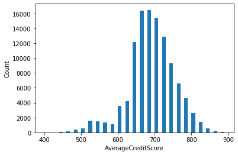

```python
#plot "Average Credit Score"
bins = np.arange(400, df.AverageCreditScore.max()+10,10)
hist(data=df, x='AverageCreditScore', bins=bins)
plt.xlabel('AverageCreditScore')
plt.ylabel('Count');
```

```python
df.AverageCreditScore.mean()
```

```
695.0677306653962
```

**Observation:** The *AverageCreditScore* was feature engineered from and **upper** and **lower** range of the Consumer Credit Rating Agencies data. Visual investgation into these ranges generally showed only a small difference.

The distribution is relatively symmetric, with an average 700 credit score. This feature will be further investigated in multivariate exploration.

**Question 4:** What is the distribution of IncomeRange of borrowers listing requests?

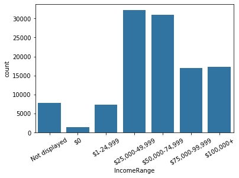

```python
# Tidying by making the Income Range a categorical ordinal dtype also fusing 0 and "not employed" to 1 bin:
df.IncomeRange.replace({'Not employed': '$0'}, inplace=True)
order = ['Not displayed','$0','$1-24,999','$25,000-49,999', '$50,000-74,999','$75,000-99,999', '$100,000+']

ranges = pd.api.types.CategoricalDtype(ordered=True, categories= order)
df.IncomeRange = df.IncomeRange.astype(ranges)

# Income Range of Borrowers
countplot(df, x='IncomeRange', x_rotation=30, figsize= (6,4))
```

It is hypothesized that higher Interest Rates for individuals below 25K lead to less requests, while high earners likely request less loans but higher amounts, to be investigated.

**Question 5:** What is the distribution of Loan Status amongst all observations in the dataset?

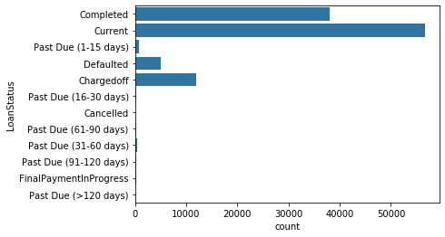

```python
# Current Loan Status
countplot(df, y='LoanStatus')
```

**Observation:** Mostly signifcant values are for "Completed", "Defaulted", and, "Chargedoff". "Current" Loans are not yet insightful for post mortem insights of a lending transaction. In the upcoming bivariate and multivariate investigation it should be focussed on the subset of this data of combined "Defaulted/Chargedoff", itself, or in relation to "Completed".

## Bivariate Exploration

**Question 6:** Do the two key Rating Systems show correlation?

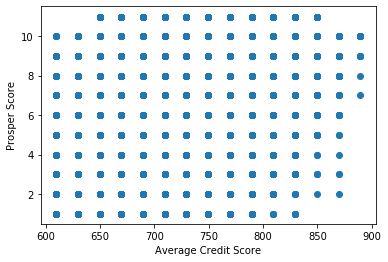

```python
# Testing correlation between Prosper Native Credit Score and Averaged Credit Score
plt.scatter(data=df[(df['LoanOriginationDate'] > '2009-07-31')] , y='ProsperScore', x='AverageCreditScore')
plt.xlabel('Average Credit Score')
plt.ylabel('Prosper Score');
```

**Observation:** Surprisingly both **rating systems do not show significant correlation**, while Prosper Rating is in regards to your insights of the data more transparent, it will be focussed on it to a larger degree, but both scores will be investigated.

**Question 7:** What is the composition of "Completed", "Defaulted", or "Chargedoff" Loans in relation to a Borrowers income?

```python
# Subset of data with only ended loan interactions - "Completed", "Defaulted", "Chargedoff"
finished_loans = df.query("LoanStatus == 'Completed' or LoanStatus == 'Defaulted' or LoanStatus == 'Chargedoff'")
```

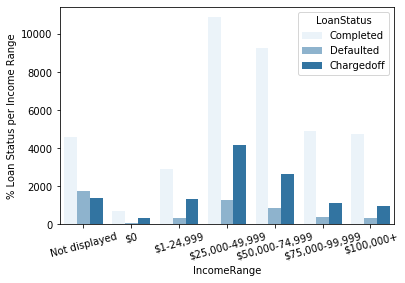

```python
# Clustered Bar Chart to investigate relationship between Income Range and Loan Outcome
countplot(finished_loans,x= 'IncomeRange', hue='LoanStatus', x_rotation=15)
plt.ylabel('% Loan Status per Income Range');
```

**Question 8:** Does BorrowerAPR differ with Homeownership?

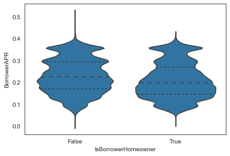

```python
# Proportion Homeowners is close to 50% - quantitative/categorical plot to investigate BorrowerAPR% for each group:
base = sb.color_palette()[0]
sb.set_style(style="white")
sb.violinplot(data=df,x='IsBorrowerHomeowner', y='BorrowerAPR', color=base,
              inner='quartile', doge=True);
```

**Observation:** Homeowner are shown to have Loans with generally lower APR.

**Question 9:** Is there a correlation between Borrower APR and Loan Outcome?

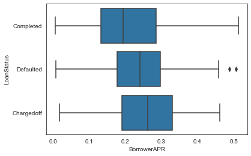

```python
# Boxplot plot to investigate the relationship between Borrower APR and Loan Outcome
sb.boxplot(data=finished_loans, x='BorrowerAPR', y='LoanStatus', color=base);
```

**Observation:** A clear effect of the Interest Rate on Loan adherence is shown, in particular *Chargedoff* Loans increase with higher Interest Rates.

**Question 10:** Is there a correlation between stated Use of Loans (Listing Category) and Loan Outcome?

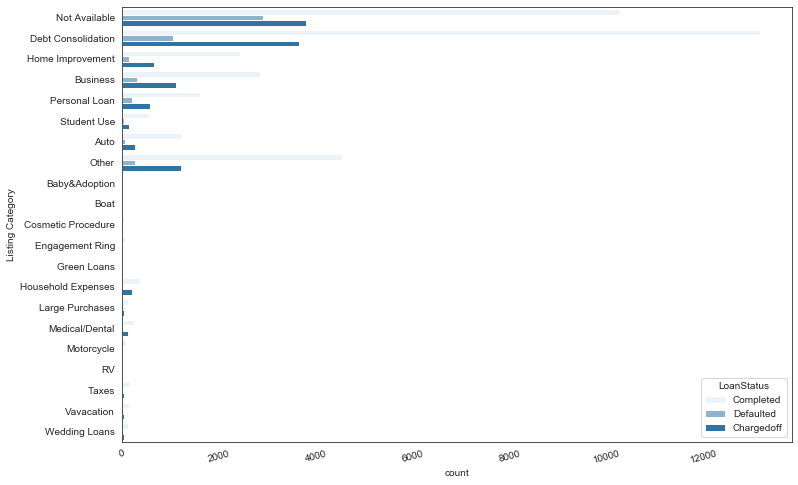

```python
# Clustered Bar Chart to investigate relationship between Listing Category and Loan Outcome
countplot(finished_loans,y= 'ListingCategory (numeric)', hue='LoanStatus', x_rotation=15, figsize=(12,8))
labels = ['Not Available', 'Debt Consolidation', 'Home Improvement', 'Business',
          'Personal Loan', 'Student Use', 'Auto', 'Other','Baby&Adoption','Boat','Cosmetic Procedure'
          , 'Engagement Ring','Green Loans', 'Household Expenses', 'Large Purchases',
          'Medical/Dental','Motorcycle','RV', 'Taxes', 'Vavacation', 'Wedding Loans']
tick_props = np.arange(0, len(labels), 1)
plt.yticks(ticks=tick_props,labels=labels)
plt.ylabel('Listing Category');
```

**Question 11:** What other columns show potental bivariate correlations? A PairGrid is plotted.

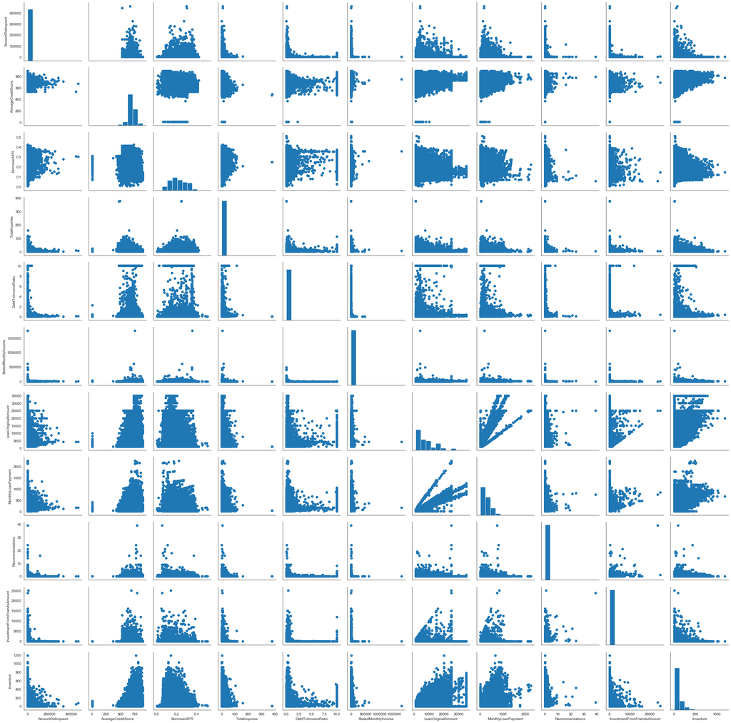

```python
# PairGrid to gain an overview of numerous quantitatives in relation to Amount Delinquent
var_list = ['AmountDelinquent','AverageCreditScore','BorrowerAPR','TotalInquiries','DebtToIncomeRatio','StatedMonthlyIncome','LoanOriginalAmount',
            'MonthlyLoanPayment','Recommendations','InvestmentFromFriendsAmount',
            'Investors']
g = sb.PairGrid(data=df, vars = var_list)
g.map_diag(plt.hist)
g.map_offdiag(plt.scatter);
```

**Observation:** The opportunity was taken to investigate relationships between various variables which surprisingly show less of a correlation than initially expected. The variable of most interest was **"Amount Deliquent"** and it showed only mild to moderate correlation overall with the relatively highest positive correlation to **BorrowerAPR**, followed my mild but likely significant correlation to **LoanOriginalAmount**, and again milder correlation with **MonthlyLoanPayment**, with an expected but only mild showing of negative correlation to the **AverageCreditScore**.

These relations will further be investigated in multivariate exploration.

## Multivariate Exploration

**Question 12:** What are the multivariate relationships between *BorrowerAPR*, *AverageCreditScore*, and *LoanStatus*?

Further investigate the relationship between *AverageCreditScore*, *OriginalAmount* and *LoanStatus*.

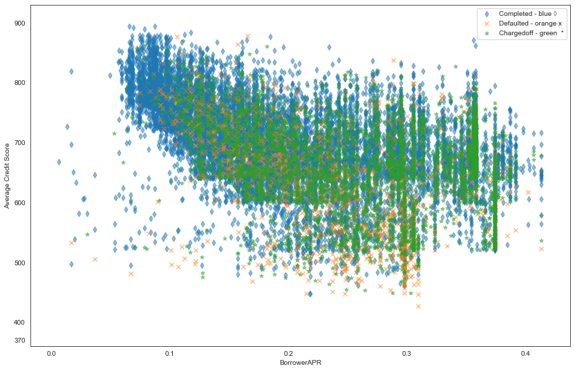

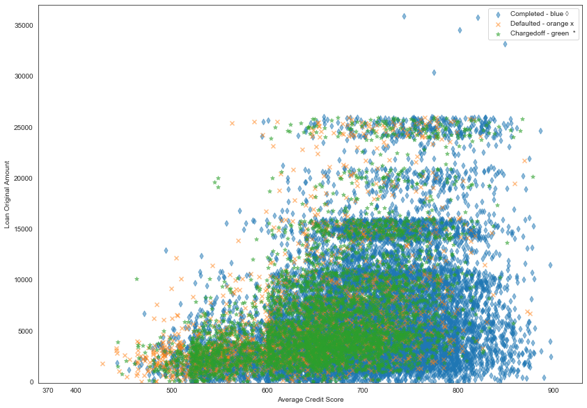

```python
# Sample to not ot overplot
len(finished_loans)
finished_loans_sample = finished_loans.sample(20000)

# Plot 1: Multivariate Scatterplot investigating relationship between BorrowerAPR,
# AverageCreditScore, and LoanStatus
plt.figure(figsize=(14, 20))

plt.subplot(2,1,1)

cat_markers = [["Completed","d"],
              ["Defaulted","x"],
              ["Chargedoff","*"]]

for cat, marker in cat_markers:
    finished_loans_cat = finished_loans_sample[finished_loans_sample['LoanStatus'] == cat]
    sb.regplot(data=finished_loans_cat, x='BorrowerAPR', y='AverageCreditScore',y_jitter=10, marker=marker, fit_reg=False, scatter_kws={'alpha':1/2})
    plt.ylim(360,930)
    plt.yticks([370,400,500,600,700,800,900])
    plt.ylabel('Average Credit Score')
    plt.xlabel('BorrowerAPR')
    marks = ['Completed - blue ◊', 'Defaulted - orange x', 'Chargedoff - green  *']
    plt.legend(marks)


# Plot2: Multivariate Scatterplot investigating relationship between, AverageCreditScore,
# OriginalAmount and Loanstatus
plt.subplot(2,1,1)
plt.figure(figsize=(14, 10))
cat_markers = [["Completed","d"],
              ["Defaulted","x"],
              ["Chargedoff","*"]]

for cat, marker in cat_markers:
    finished_loans_cat = finished_loans_sample[finished_loans_sample['LoanStatus'] == cat]
    sb.regplot(data=finished_loans_cat, x='AverageCreditScore', y='LoanOriginalAmount',x_jitter=10, y_jitter=1000, marker=marker, fit_reg=False, scatter_kws={'alpha':1/2})
    plt.xlim(360,930)
    plt.ylim(-100,37000)
    plt.xticks([370,400,500,600,700,800,900])
    plt.xlabel('Average Credit Score')
    plt.ylabel('Loan Original Amount')
    #marks = ['Completed', 'Defaulted', 'Chargedoff']
    plt.legend(marks)
```

**Observation:** *Borrower APR* shows a strong correlation with *Average Credit Score* and *Loan Outcome*. In the first subplot a lower Interest Rate shows a higher proportion of honored *Completed* Loans (blue diamonds), which are also higher, the higher the *Average Credit Score* is. The opposite is the case for *Chargedoff*, and *Defaulted* Loans.

In the latter subplot the *Average Credit Score* is the key factor for *Loan Outcome* while the *Loan Original Amount* appears to play a subordinate role, while density appears to be higher with lower original loan amounts.

**Question 13:** What is the effectiveness of the *Prosper Score* in predicting *Delinquent Payments* per *Loan Amount*?

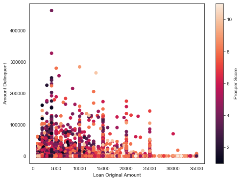

```python
plt.figure(figsize=(8, 6))
plt.scatter(data=df, y='AmountDelinquent', x='LoanOriginalAmount', c = 'ProsperScore')
plt.ylabel('Amount Delinquent')
plt.xlabel('Loan Original Amount')

plt.colorbar(label='Prosper Score');
```

**Observation** The score appears effective as higher scored borrowers show less delinquent payments across the range of *Loan Amounts*.

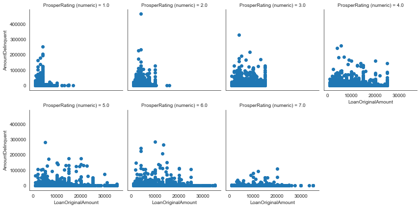

```python
# Since the AverageCreditScore and the ProsperScore do not show significant correlation,
#the effectiveness of the ProsperRating is investigated

plt.rcParams["figure.figsize"] =(12, 8)
g =sb.FacetGrid(data=df, col= 'ProsperRating (numeric)', col_wrap=4)
g.map(plt.scatter, 'LoanOriginalAmount', 'AmountDelinquent');
#[plt.setp(ax.get_xticklabels(), rotation=15) for ax in g.axes.flat];
```

**Question 15:** What is the outcome of loans - *Loan Status* - per *Loan Amount* for differently rated borrowers (*Prosper Rating*)?

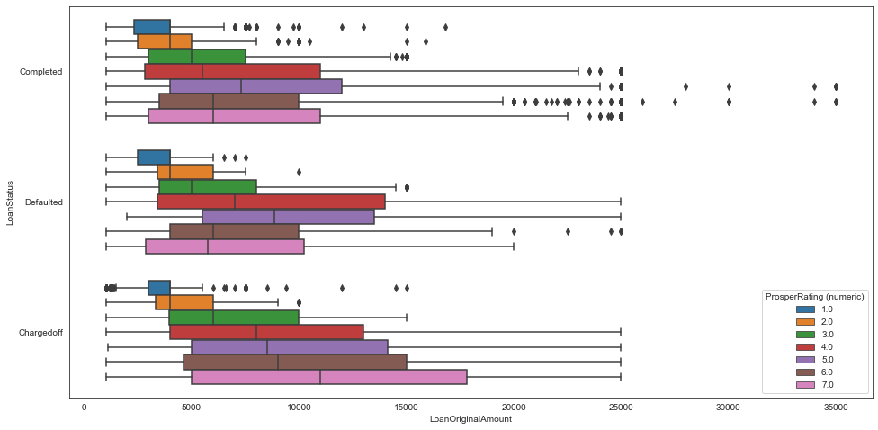

```python
# Boxplot plot to investigate the relationship between Borrower APR, Loan Outcome, and Prosper Rating
plt.figure(figsize=(16, 8))
sb.boxplot(data=finished_loans, x='LoanOriginalAmount', y='LoanStatus', hue='ProsperRating (numeric)');
```

**Question 16:** Do Borrowers use the full length of their Loan agreement - *Term* - and how does this differ in differently rated Borrowers?

```python
# timespan of the loan for finished loans
finished_loans['Timespan'] = finished_loans['ClosedDate'] - finished_loans['LoanOriginationDate']
# first convert the timespan to days to later convert to month for comparison in heatmap with agreed term
finished_loans.Timespan = finished_loans.Timespan.dt.days
# Extreme outliers/erros below zero are cut
finished_loans.Timespan = finished_loans.Timespan.mask(finished_loans.Timespan < 0, 0)
# conversion to months by division of average days per month in year (30,437)
finished_loans.Timespan = finished_loans.Timespan/30.437

# Visual of Timespan of finished loans - "finished" is used as definition for post loan analysis to not to confuse transactions
# with "completed" loans that are a subset of "finished" loans, which have been repaid in full in due time
```

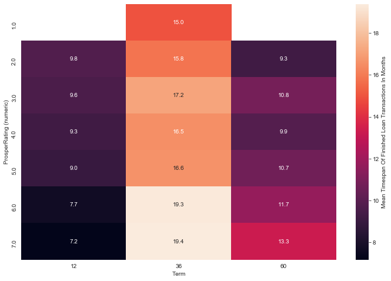

```python
# Heatmap to display multivariate relations of ProsperRating, Term, and Timespan
plt.figure(figsize=(12, 8))
cat_means = finished_loans.groupby(['Term','ProsperRating (numeric)']).mean()['Timespan']
cat_means = cat_means.reset_index(name='Mean Timespan in months')
cat_means = cat_means.pivot(index = 'ProsperRating (numeric)', values= 'Mean Timespan in months', columns='Term')

sb.heatmap(cat_means, annot = True, fmt = '.1f',
          cbar_kws = {'label' : 'Mean Timespan Of Finished Loan Transactions In Months'});
```

**Observation:** After having evaluated Prosper Score and Prosper Rating as effective benchmarks earlier, for estimating the creditors/lenders needed of working capital/liquidity, a subset of the dataframe that only considers finished loans - *completed, defaulted, or chargedoff* - was investigated that compared the actual **times of the loan** with the **Term (length of agreed loan contract)** in relation to the **Prosper Rating**.

## Conclusions

The key findings are that the Prosper Rating and Score are fairly accurate for lenders to predict loan outcome an and therefore risk and profit margins.This rating system does not align with the rating of the Consumer Credit Agency, which needed to be evaluated differently. A major underlying causality for these outcomes however are the higher Interest rates for lower rated Borrowers. Further, the final observation that showed that loans are finished in most cases prior to the end of the term of the loan agreement allow a more efficient capital allocation for lenders.